# Исследование объявлений о продаже квартир

#### Как зависит цена от того, на каком этаже расположена квартира: первом, последнем или другом.

```
(0.015, 0.2)
```

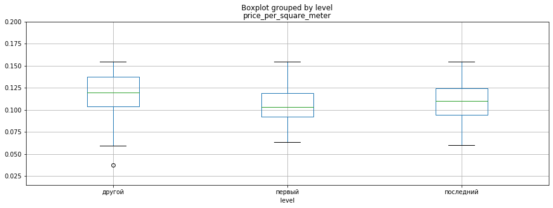

```python
spb_center.boxplot(column = 'price_per_square_meter', by = 'level', figsize=(15,5))
plt.ylim(0.015, 0.2)
```

График, показывает, что медианная цена м2. для квартир на первых и последних этажах немного ниже, чем на остальных. Первый этаж дешевле последнего.

#### Как зависит цена от даты размещения: дня недели, месяца и года.

```
(0.015, 0.2)
```

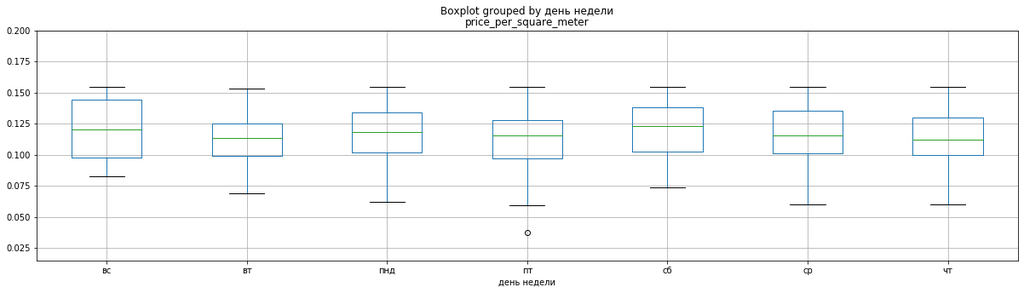

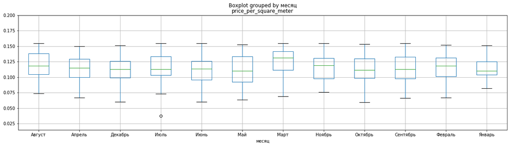

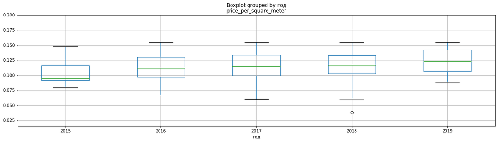

```python
spb_center.boxplot(column = 'price_per_square_meter', by = 'день недели', figsize = (20,5))
plt.ylim(0.015, 0.2)
spb_center.boxplot(column = 'price_per_square_meter', by = 'месяц', figsize = (20,5))
plt.ylim(0.015, 0.2)
spb_center.boxplot(column = 'price_per_square_meter', by = 'год', figsize = (20,5))
plt.ylim(0.015, 0.2)
```

Проанализировав, сделаем вывод:

1. Зависимости цен от дня недели различается незначительно.
2. От месяца: в Марте медианная цена самая большая, а в Мае самая низкая(вероятнее всего, что майские праздники). В остальных месяцах разница незначительная.
3. От года - вполне ожидаемо (рост цен примерно равен инфляции за каждый год, относительно предыдущего года).

Построим матрицу рассеивания:

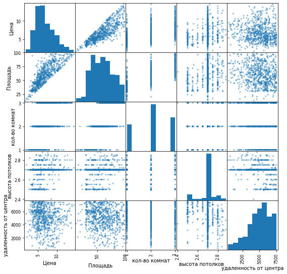

```python
pd.plotting.scatter_matrix(spb_center[column], figsize=(9,9));
```

Потверждаем предыдущие выводы

## Общий вывод

Цена на квартиру, как в Ленинградской области, так и в центре города зависит:

- В первую очередь от площади квартиры (разницы зависимости цены от площади между областью и центром города практически нету).
- Во второй степени - от колличества комнат (зависимость между областью и центром города нету разницы).
- От удалённости от центра - чем дальше она от него, тем дешевле её стоимость.
- Остальные факторы оказывают на ценообразование меньшее влияние.

Тем не менее, на цену влияют пассивные факторы, такие как: год постройки квартиры, удалённость от основных дорог, метро, детских садов, школ, и т.п. К сожалению их нету в датафрейме, чтобы проанализировать их.

При работе с дасетом были выполнены следующие действия:

- Проанализирован датасет
- объяснены предположения по природе пропусков.
- Определены и изучены пропущенные значения, данные приведены к нужным типам и удалены дубликаты.
- Посчитаны и добавлены в таблицу: цена квадратного метра, дата публикации, соотношение жилой и общей площади, для того, чтобы проанализировать, зависит ли цена от месяца публикации или дня недели (разбили дату на день/месяц/год).
- Автоматизировано построение гистограмм и коробчатых графиков.
- Проведен исследовательский анализ данных с дальнейшими выводами, в котором мы изучили основные зависимости цены от других факторов, как в Ленинградской области, так и в центре самого Санкт-Петербурга.

## Чек-лист готовности проекта

Поставьте 'x' в выполненных пунктах. Далее нажмите Shift+Enter.

- [x] открыт файл
- [x] файлы изучены (выведены первые строки, метод info())
- [x] определены пропущенные значения
- [x] заполнены пропущенные значения
- [x] есть пояснение, какие пропущенные значения обнаружены
- [x] изменены типы данных
- [x] есть пояснение, в каких столбцах изменены типы и почему
- [x] посчитано и добавлено в таблицу: цена квадратного метра
- [x] посчитано и добавлено в таблицу: день недели, месяц и год публикации объявления
- [x] посчитано и добавлено в таблицу: этаж квартиры; варианты — первый, последний, другой
- [x] посчитано и добавлено в таблицу: соотношение жилой и общей площади, а также отношение площади кухни к общей
- [x] изучены следующие параметры: площадь, цена, число комнат, высота потолков
- [x] построены гистограммы для каждого параметра
- [x] выполнено задание: "Изучите время продажи квартиры. Постройте гистограмму. Посчитайте среднее и медиану. Опишите, сколько обычно занимает продажа. Когда можно считать, что продажи прошли очень быстро, а когда необычно долго?"
- [x] выполнено задание: "Уберите редкие и выбивающиеся значения. Опишите, какие особенности обнаружили."
- [x] выполнено задание: "Какие факторы больше всего влияют на стоимость квартиры? Изучите, зависит ли цена от квадратного метра, числа комнат, этажа (первого или последнего), удалённости от центра. Также изучите зависимость от даты размещения: дня недели, месяца и года. "Выберите 10 населённых пунктов с наибольшим числом объявлений. Посчитайте среднюю цену квадратного метра в этих населённых пунктах. Выделите населённые пункты с самой высокой и низкой стоимостью жилья. Эти данные можно найти по имени в столбце '*locality_name'*. "
- [x] выполнено задание: "Изучите предложения квартир: для каждой квартиры есть информация о расстоянии до центра. Выделите квартиры в Санкт-Петербурге (*'locality_name'*). Ваша задача — выяснить, какая область входит в центр. Создайте столбец с расстоянием до центра в километрах: округлите до целых значений. После этого посчитайте среднюю цену для каждого километра. Постройте график: он должен показывать, как цена зависит от удалённости от центра. Определите границу, где график сильно меняется — это и будет центральная зона. "
- [x] выполнено задание: "Выделите сегмент квартир в центре. Проанализируйте эту территорию и изучите следующие параметры: площадь, цена, число комнат, высота потолков. Также выделите факторы, которые влияют на стоимость квартиры (число комнат, этаж, удалённость от центра, дата размещения объявления). Сделайте выводы. Отличаются ли они от общих выводов по всему городу?"
- [x] в каждом этапе есть выводы
- [x] есть общий вывод